# Loan Risk Prediction

Achmad Gunar Saadi

September 13, 2018

# 1 Introduction

## 1.1 Objectives

**Project: Loan Risk Prediction**

Use any of the 3 classification algorithms (Naive-Bayes, Decision Tree, or Random Forest) to predict the risk status of a bank loan. The variable **default** in the dataset indicates whether the applicant did default on the loan issued by the bank. Start by reading the `loan.csv` dataset in your file Classification in Machine Learning 2 course materials, a dataset that is originally from Professor Dr. Hans Hofmann.

As guidance for good result as below:  
- The pre-processing steps are done, and holding out a test / cross validation set for an estimate of the model’s performance on unseen data - The model’s performance is sufficiently explained (accuracy may not be the most helpful metric here! - Demonstrating extra effort in evaluating his/her model, and proposes ways to improve the accuracy obtained from the initial model.

## 1.2 Data Explanation

This dataset classifies people described by a set of attributes as good or bad credit risks. The response variable is **default**.  
The dataset is originally from Professor Dr. Hans Hofmann and comprises 17 variables as follow:

**checking_balance**: Status of existing checking  
**months_loan_duration**: Duration in month  
**credit_history**: Between critical, good, perfect, poor and very good  
**purpose**: Between business, car(new), car(used), education, furniture and renovations  
**amount**: Credit amount  
**savings_balance**: Status of existing savings account  
**employment_duration**: Present employment since  
**percent_of_income**: Installment rate in percentage of disposable income  
**years_at_residence**: Present residence since  
**Age**: Age applicant in year  
**other_credit**: Other installment plans (bank / store)  
**housing**: Between rent, own, or for free  
**existing_loans_count**: Number of existing credits at this bank  
**job**: Between management, skilled, unskilled and unemployed  
**dependents**: Number of people being liable to provide maintenance for  
**phone**: Between none and yes (registered under customer name)  
**default**: whether the applicant did default on the loan issued by the bank (yes or no)

## 1.3 Read and understand the Dataset

This is how the data look like (I only display the first 6 data) and including the 17 variables mentioned before and 1000 observations.

```r
loans <- read.csv("./loan.csv")
head(loans)
```

```
##   checking_balance months_loan_duration credit_history
## 1           < 0 DM                    6       critical
## 2       1 - 200 DM                   48           good
## 3          unknown                   12       critical
## 4           < 0 DM                   42           good
## 5           < 0 DM                   24           poor
## 6          unknown                   36           good
##                purpose amount savings_balance employment_duration
## 1 furniture/appliances   1169         unknown           > 7 years
## 2 furniture/appliances   5951        < 100 DM         1 - 4 years
## 3            education   2096        < 100 DM         4 - 7 years
## 4 furniture/appliances   7882        < 100 DM         4 - 7 years
## 5                  car   4870        < 100 DM         1 - 4 years
## 6            education   9055         unknown         1 - 4 years
##   percent_of_income years_at_residence age other_credit housing
## 1                 4                  4  67         none     own
## 2                 2                  2  22         none     own
## 3                 2                  3  49         none     own
## 4                 2                  4  45         none   other
## 5                 3                  4  53         none   other
## 6                 2                  4  35         none   other
##   existing_loans_count       job dependents phone default
## 1                    2   skilled          1   yes      no
## 2                    1   skilled          1    no     yes
## 3                    1 unskilled          2    no      no
## 4                    1   skilled          2    no      no
## 5                    2   skilled          2    no     yes
## 6                    1 unskilled          2   yes      no
```

```r
str(loans)
```

```
## 'data.frame':    1000 obs. of  17 variables:
##  $ checking_balance    : Factor w/ 4 levels "< 0 DM","> 200 DM",..: 1 3 4 1 1 4 4 3 4 3 ...
##  $ months_loan_duration: int  6 48 12 42 24 36 24 36 12 30 ...
##  $ credit_history      : Factor w/ 5 levels "critical","good",..: 1 2 1 2 4 2 2 2 2 1 ...
##  $ purpose             : Factor w/ 6 levels "business","car",..: 5 5 4 5 2 4 5 2 5 2 ...
##  $ amount              : int  1169 5951 2096 7882 4870 9055 2835 6948 3059 5234 ...
##  $ savings_balance     : Factor w/ 5 levels "< 100 DM","> 1000 DM",..: 5 1 1 1 1 5 4 1 2 1 ...
##  $ employment_duration : Factor w/ 5 levels "< 1 year","> 7 years",..: 2 3 4 4 3 3 2 3 4 5 ...
##  $ percent_of_income   : int  4 2 2 2 3 2 3 2 2 4 ...
##  $ years_at_residence  : int  4 2 3 4 4 4 4 2 4 2 ...
##  $ age                 : int  67 22 49 45 53 35 53 35 61 28 ...
##  $ other_credit        : Factor w/ 3 levels "bank","none",..: 2 2 2 2 2 2 2 2 2 2 ...
##  $ housing             : Factor w/ 3 levels "other","own",..: 2 2 2 1 1 1 2 3 2 2 ...
##  $ existing_loans_count: int  2 1 1 1 2 1 1 1 1 2 ...
##  $ job                 : Factor w/ 4 levels "management","skilled",..: 2 2 4 2 2 4 2 1 4 1 ...
##  $ dependents          : int  1 1 2 2 2 2 1 1 1 1 ...
##  $ phone               : Factor w/ 2 levels "no","yes": 2 1 1 1 1 2 1 2 1 1 ...
##  $ default             : Factor w/ 2 levels "no","yes": 1 2 1 1 2 1 1 1 1 2 ...
```

The dataset comprises integer and factor data-type from str().

# 2 Exploring the Data

## 2.1 Quick Look the data

By using summary(), we can tell that each variables has various range of value each other. There is no missing value (NA) in the dataset therefore doesn’t need to data imputing process.

```r
summary(loans)
```

```
##    checking_balance months_loan_duration   credit_history
##  < 0 DM    :274     Min.   : 4.0         critical :293
##  > 200 DM  : 63     1st Qu.:12.0         good     :530
##  1 - 200 DM:269     Median :18.0         perfect  : 40
##  unknown   :394     Mean   :20.9         poor     : 88
##                     3rd Qu.:24.0         very good: 49
##                     Max.   :72.0
##                  purpose        amount           savings_balance
##  business            : 97   Min.   :  250   < 100 DM     :603
##  car                 :337   1st Qu.: 1366   > 1000 DM    : 48
##  car0                : 12   Median : 2320   100 - 500 DM :103
##  education           : 59   Mean   : 3271   500 - 1000 DM: 63
##  furniture/appliances:473   3rd Qu.: 3972   unknown      :183
##  renovations         : 22   Max.   :18424
##   employment_duration percent_of_income years_at_residence      age
##  < 1 year   :172      Min.   :1.000     Min.   :1.000      Min.   :19.00
##  > 7 years  :253      1st Qu.:2.000     1st Qu.:2.000      1st Qu.:27.00
##  1 - 4 years:339      Median :3.000     Median :3.000      Median :33.00
##  4 - 7 years:174      Mean   :2.973     Mean   :2.845      Mean   :35.55
##  unemployed : 62      3rd Qu.:4.000     3rd Qu.:4.000      3rd Qu.:42.00
##                       Max.   :4.000     Max.   :4.000      Max.   :75.00
##  other_credit  housing    existing_loans_count         job
##  bank :139    other:108   Min.   :1.000        management:148
##  none :814    own  :713   1st Qu.:1.000        skilled   :630
##  store: 47    rent :179   Median :1.000        unemployed: 22
##                           Mean   :1.407        unskilled :200
##                           3rd Qu.:2.000
##                           Max.   :4.000
##    dependents    phone     default
##  Min.   :1.000   no :596   no :700
##  1st Qu.:1.000   yes:404   yes:300
##  Median :1.000
##  Mean   :1.155
##  3rd Qu.:1.000
##  Max.   :2.000
```

```r
anyNA(loans)
```

```
## [1] FALSE
```

## 2.2 Train and Test dataset

Split the data set into train set (80%) and Test set (20%) by previously shuffle the order of the row of to get unbiased result.

```r
# Proportion:
# ************************
# 80% train and 20% test
# ************************
set.seed(123)
ind_intrain <- sample(nrow(loans), nrow(loans)*0.8)
loans_train <- loans[ind_intrain, ]
loans_test <- loans[-ind_intrain, ]
```

```r
train_labels <- loans[ind_intrain, 17]
test_labels <- loans[-ind_intrain, 17]
prop.table(table(train_labels))
```

```
## train_labels
##     no    yes
## 0.7025 0.2975
```

```r
prop.table(table(test_labels))
```

```
## test_labels
##   no  yes
## 0.69 0.31
```

As the above code run, the proportion of the target variable in train and test dataset is dominated by default=no with quite similar proportion.

## 2.3 Naive-Bayes Method

```r
library(e1071)
loans_model <- naiveBayes(default ~ ., loans_train)
loans_prediction <- predict(loans_model, loans_test[,-17])
```

### 2.3.1 Evaluation of Performance

```r
table("prediction"=loans_prediction, "actual"=loans_test$default)
```

```
##           actual
## prediction  no yes
##        no  118  33
##        yes  20  29
```

```r
# accuracy
sum(loans_prediction == test_labels)/nrow(loans_test)
```

```
## [1] 0.735
```

From the table above we can gain information: Accuracy= (118+29)/(118+33+20+29)=147/200= 73.5% Recall(sensitivity or true positive rate) = 29/(29+33)=29/62= 46.77% Precision= 29/(29+20)=29/49= 59.18% Specificity (true negative rate)= 118/(118+20)=118/138= 85.51%

### 2.3.2 ROC Curve

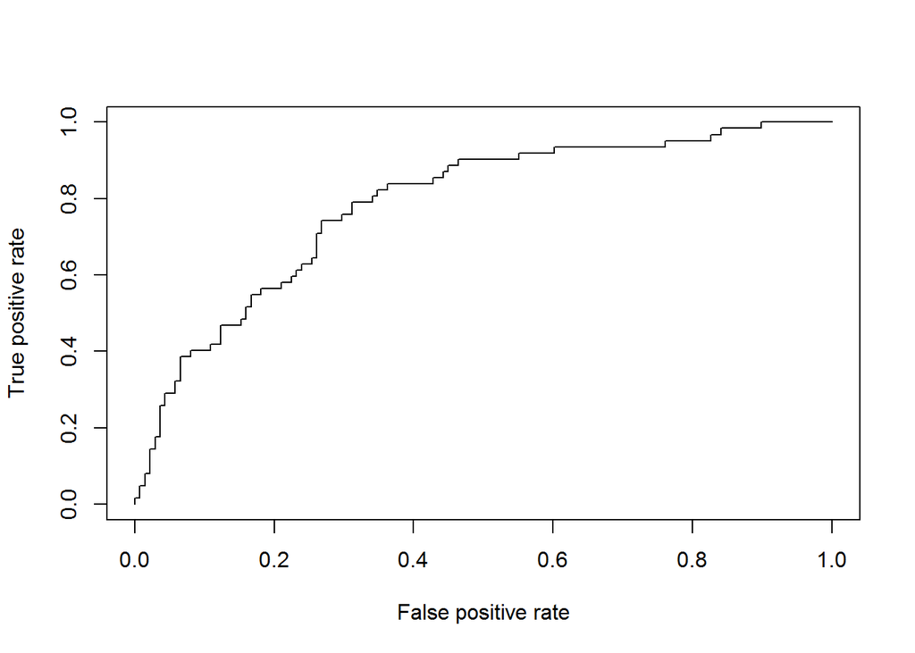

```r
loan_pred_raw<-predict(loans_model,loans_test,type = "raw")
loans_df<-data.frame("prediction"=loan_pred_raw[,2],"trueValue"=as.numeric(test_labels=="yes"))
##plot ROC Curve
library(ROCR)
loans_roc<-ROCR::prediction(loans_df$prediction,loans_df$trueValue)
plot(performance(loans_roc,"tpr","fpr"))
```

## 2.4 Decision Tree

```r
library(partykit)
```

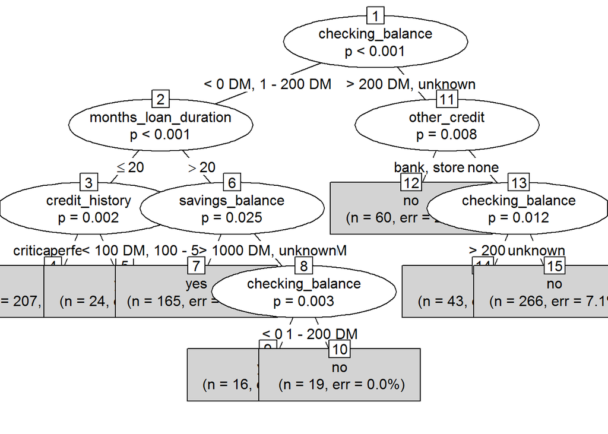

```r
loans_tree_model <- ctree(default ~ ., loans_train)
plot(loans_tree_model,type="simple")
```

```r
loans_tree_model
```

```
##
## Model formula:
## default ~ checking_balance + months_loan_duration + credit_history +
##     purpose + amount + savings_balance + employment_duration +
##     percent_of_income + years_at_residence + age + other_credit +
##     housing + existing_loans_count + job + dependents + phone
##
## Fitted party:
## [1] root
## |   [2] checking_balance < 0 DM, 1 - 200 DM
## |   |   [3] months_loan_duration <= 20
## |   |   |   [4] credit_history in critical, good, poor: no (n = 207, err = 31.9%)
## |   |   |   [5] credit_history in perfect, very good: yes (n = 24, err = 25.0%)
## |   |   [6] months_loan_duration > 20
## |   |   |   [7] savings_balance < 100 DM, 100 - 500 DM, 500 - 1000 DM: yes (n = 165, err = 39.4%)
## |   |   |   [8] savings_balance > 1000 DM, unknown
## |   |   |   |   [9] checking_balance < 0 DM: yes (n = 16, err = 43.8%)
## |   |   |   |   [10] checking_balance in 1 - 200 DM: no (n = 19, err = 0.0%)
## |   [11] checking_balance > 200 DM, unknown
## |   |   [12] other_credit in bank, store: no (n = 60, err = 26.7%)
## |   |   [13] other_credit in none
## |   |   |   [14] checking_balance > 200 DM: no (n = 43, err = 23.3%)
## |   |   |   [15] checking_balance in unknown: no (n = 266, err = 7.1%)
##
## Number of inner nodes:    7
## Number of terminal nodes: 8
```

```r
width(loans_tree_model)
```

```
## [1] 8
```

```r
depth(loans_tree_model)
```

```
## [1] 4
```

```r
loans_tree_prediction<-predict(loans_tree_model, loans_test[,-17])
```

### 2.4.1 Evaluation of performance

```r
table("prediction"=loans_tree_prediction, "actual"=loans_test$default)
```

```
##           actual
## prediction  no yes
##        no  120  32
##        yes  18  30
```

```r
#accuracy
sum(loans_tree_prediction == test_labels)/nrow(loans_test)
```

```
## [1] 0.75
```

### 2.4.2 ROC Curve

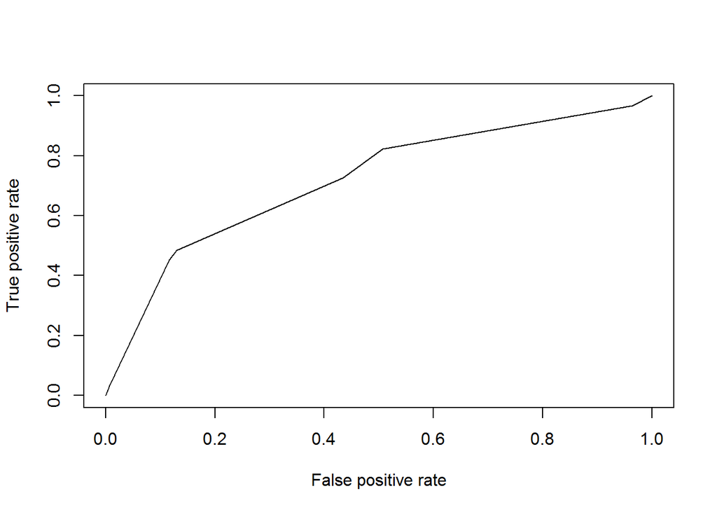

```r
loans_tree_pred_raw<-predict(loans_tree_model, loans_test[,-17], type="prob")
loans_tree_df<-data.frame("prediction"=loans_tree_pred_raw[,2],"trueValue"=as.numeric(test_labels=="yes"))

##plot ROC Curve
loans_tree_roc<-ROCR::prediction(loans_tree_df$prediction,loans_tree_df$trueValue)
plot(performance(loans_tree_roc,"tpr","fpr"))
```

## 2.5 Random Forest

```r
library(caret)
# This process can be time-consuming
set.seed(111)
ctrl <- trainControl(method="repeatedcv", number=5, repeats=3)
## allowparalel=TRUE
loans_forest <- train(default ~ ., data=loans_train, method="rf", trainControl = ctrl)
saveRDS(loans_forest,file="loans_forest.RDS")
```

```r
loans_forest <-readRDS("loans_forest.RDS")
```

```r
loans_forest
```

```
## Random Forest
##
## 800 samples
##  16 predictor
##   2 classes: 'no', 'yes'
##
## No pre-processing
## Resampling: Bootstrapped (25 reps)
## Summary of sample sizes: 800, 800, 800, 800, 800, 800, ...
## Resampling results across tuning parameters:
##
##   mtry  Accuracy   Kappa
##    2    0.7172006  0.1083893
##   18    0.7277399  0.2859108
##   35    0.7201242  0.2807911
##
## Accuracy was used to select the optimal model using the largest value.
## The final value used for the model was mtry = 18.
```

As have shown above, the largest accuracy gained when random forest using mtry=18, or 18 variables each node splitting. That thing also can be visualized by using plot() function.

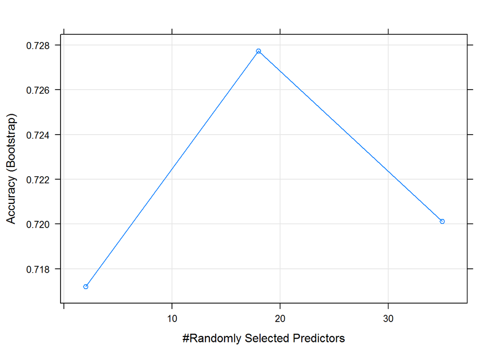

```r
plot(loans_forest)
```

From the picture, the 18 randomly predictors has the largest accuracy.

### 2.5.1 Evaluation of performance

```r
loans_forest_prediction <- predict(loans_forest, loans_test[,-17])
table("prediction"=loans_forest_prediction, "actual"=loans_test$default)
```

```
##           actual
## prediction  no yes
##        no  128  36
##        yes  10  26
```

```r
# Check accuracy
sum(loans_forest_prediction == test_labels)/nrow(loans_test)
```

```
## [1] 0.77
```

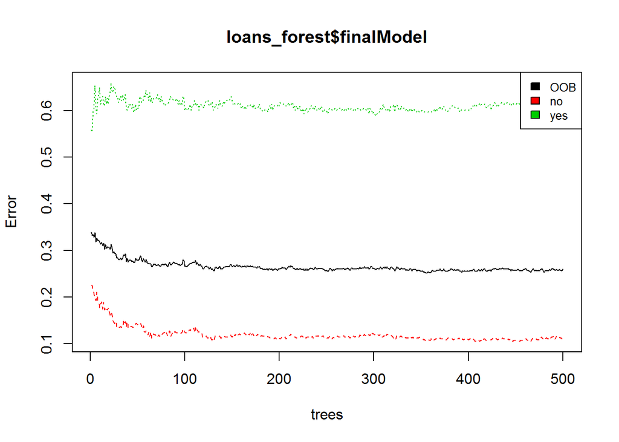

```r
plot(loans_forest$finalModel)
legend("topright", colnames(loans_forest$finalModel$err.rate),col=1:3,cex=0.8,fill=1:3)
```

The picture shows that basically random forest has a feature out-of-bag (OOB) estimates inside it. Therefore, there is no need to split the dataset into training and test set beforehand. That is why the black line in the diagram shows the lower error rate than the green line.

# 3 Conclusion

From the confusion matrix to evaluate the perform between naive-bayes, decision tree, and random forest as follow:

**Naive-Bayes Method**  
`Accuracy`= (118+29)/(118+33+20+29)=147/200= `73.5%`  
`Recall(sensitivity or true positive rate)`= 29/(29+33)=29/62= `46.77%`  
`Precision`= 29/(29+20)=29/49= `59.18%`  
`Specificity (true negative rate)`= 118/(118+20)=118/138= `85.51%`

**There are some ways to be considered to improve the model that have obtained:**

**Naive-Bayes Method**

- Wheter use smooting or not and the smoothing type
- The type of data standardization or normalization used
- The proportion of training and test set splitting

**Decision Tree**

- The setting of Ctree Control parameters (mincriterion, minspit, minbucket)
- The proportion of training and test set splitting
- The depth parameter chosen
- The type of data standardization or normalization used

**Random Forest**

- Whether split the dataset into training and test set previously or not (using OOB estimates feature in random forest)
- The feature selection (one of examples by using nearZeroVar() function)
- The number of cross-validation and repeats in trainControl() function